# Linear Algebra for Data Science

## Part 4: Eigenvalues, Eigenvectors & Dimensionality Reduction using PCA

In this notebook, we will cover:

1. **Eigenvalues & Eigenvectors**
   - Definition: $ A \mathbf{v} = \lambda \mathbf{v} $
   - Importance in data science (directions of principal variance, stability in systems, etc.)
   - Hands-On: Using `numpy.linalg.eig` on a small matrix
2. **Principal Component Analysis (PCA)**
   - Covariance matrix: formation & eigen-decomposition
   - Dimensionality reduction: capturing most variance in fewer dimensions
   - Hands-On:
     - Manual computation of covariance & eigen-decomposition on a real or synthetic dataset
     - Comparison with scikit-learn’s PCA

```python
import numpy as np
import matplotlib.pyplot as plt
from sklearn.datasets import load_iris
```

## 1. Eigenvalues & Eigenvectors

### 1.1 Definition

For a square matrix $A$ of shape $(n \times n)$ and a **non-zero** vector $\mathbf{v}$ of size $n$, if:

$$ A \mathbf{v} = \lambda \mathbf{v}, $$

then:

- $\lambda$ is called an **eigenvalue** of $A$.
- $\mathbf{v}$ is the corresponding **eigenvector**.

### 1.2 Why Important in Data Science?

- **Principal Component Analysis (PCA)** uses the eigenvectors/eigenvalues of the **covariance matrix** to find directions of maximum variance in data.
- **Stability**: In dynamical systems or Markov chains, eigenvalues describe equilibrium and long-term behavior.
- **Dimensionality Reduction**: The eigenvectors can represent “principal directions”; largest eigenvalues correspond to largest variance directions.

### 1.3 Hands-On with a Small Matrix

```python
# Let's define a simple 2x2 matrix
A_2x2 = np.array([[4, 2],
                  [1, 3]])

print("Matrix A_2x2:\n", A_2x2)
```

```
Matrix A_2x2:
 [[4 2]
 [1 3]]
```

```python
# Compute eigenvalues & eigenvectors
eigenvalues, eigenvectors = np.linalg.eig(A_2x2)
print("\nEigenvalues:", eigenvalues)
print("Eigenvectors:\n", eigenvectors)
```

```
Eigenvalues: [5. 2.]
Eigenvectors:
 [[ 0.89442719 -0.70710678]
 [ 0.4472136   0.70710678]]
```

- `eigenvalues` is an array like $[\lambda_1, \lambda_2]$.
- `eigenvectors` is a 2×2 matrix where each **column** is an eigenvector corresponding to an eigenvalue in `eigenvalues`.

**Verification** (optional):

- We can verify $A \mathbf{v} \approx \lambda \mathbf{v}$ for each pair $(\lambda, \mathbf{v})$.

### 1.4 Visualizing the Transformation

A 2D transformation can be visualized by applying $A$ to a grid of points, but let’s keep it simple here. We'll:

1. Plot a set of vectors in 2D.
2. Multiply by $A$.
3. Show how eigenvectors are scaled (not rotated) when multiplied by $A$.

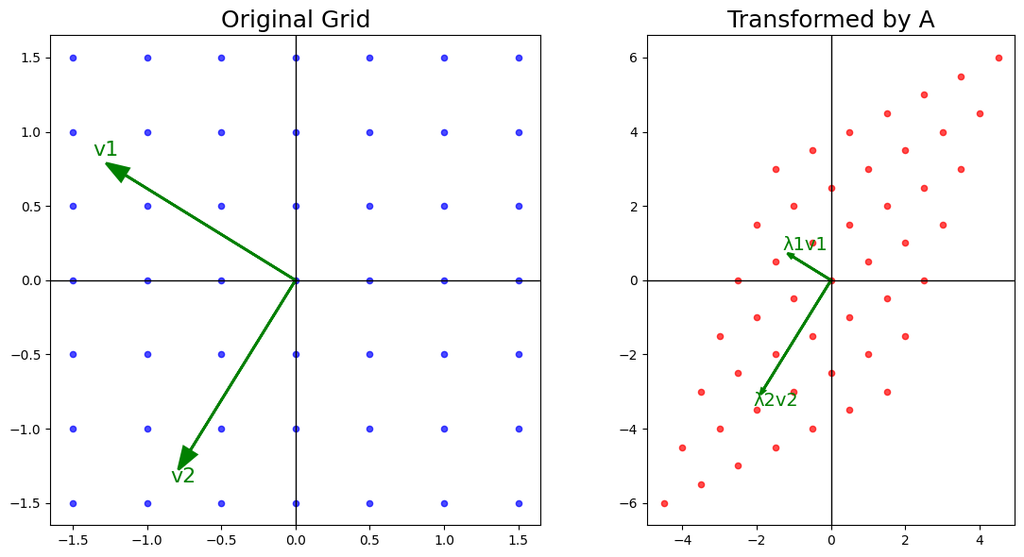

```python
import numpy as np
import matplotlib.pyplot as plt

# Define a 2D transformation matrix
A = np.array([[2, 1],
              [1, 3]])

# 1. Create a grid of points
N = 11  # how many points in each axis
x_vals = np.arange(-1.5, 2, 0.5)
y_vals = np.arange(-1.5, 2, 0.5)

X, Y = np.meshgrid(x_vals, y_vals)

# Stack all points into an (N*N, 2) array for matrix multiplication
points = np.stack([X.ravel(), Y.ravel()], axis=1)  # shape: (N*N, 2)

# 2. Transform the points by A
transformed_points = points @ A.T  # shape: (N*N, 2)

# 3. Compute eigenvalues & eigenvectors
eigvals, eigvecs = np.linalg.eig(A)

# Plot the results side-by-side
fig, axes = plt.subplots(1, 2, figsize=(12, 6))
axes[0].scatter(points[:, 0], points[:, 1], s=20, alpha=0.7, color='blue')
axes[0].axhline(0, color='black', linewidth=1)
axes[0].axvline(0, color='black', linewidth=1)
axes[0].set_title("Original Grid", fontsize=18)
axes[0].set_aspect('equal', 'box')

# Plot eigenvectors (from origin) on the original grid
for i in range(len(eigvals)):
    vec = eigvecs[:, i]
    # We'll draw a simple arrow indicating the direction of the eigenvector
    axes[0].arrow(0, 0, vec[0] * 1.5, vec[1] * 1.5, head_width=0.1, color='green', lw=2, length_includes_head=True)
    axes[0].text(vec[0]*1.6, vec[1]*1.6, f"v{i+1}", fontsize=16, color='green')

axes[1].scatter(transformed_points[:, 0], transformed_points[:, 1], s=20, alpha=0.7, color='red')
axes[1].axhline(0, color='black', linewidth=1)
axes[1].axvline(0, color='black', linewidth=1)
axes[1].set_title("Transformed by A", fontsize=18)
axes[1].set_aspect('equal', 'box')

# Show how eigenvectors get scaled by eigenvalues in the transformed space
# For each eigenvector v, A * v = lambda * v (so it should end up at (lambda*v))
for i in range(len(eigvals)):
    lambda_i = eigvals[i]
    vec = eigvecs[:, i]
    transformed_vec = A @ vec  # which should be same as lambda_i * vec
    # transformed_vec = lambda_i*vec

    axes[1].arrow(0, 0, transformed_vec[0], transformed_vec[1],
                  head_width=0.1, color='g', lw=2,
                  length_includes_head=True)
    axes[1].text(transformed_vec[0]*1.1, transformed_vec[1]*1.1, f"λ{i+1}v{i+1}", fontsize=14, color='g')

plt.tight_layout()
plt.show()
```

```python
eigvals, eigvecs
```

```
(array([1.38196601, 3.61803399]),
 array([[-0.85065081, -0.52573111],
        [ 0.52573111, -0.85065081]]))
```

## 2. Principal Component Analysis (PCA)

#### Applications of Principal Component Analysis (PCA)

1. **Feature Reduction & Noise Filtering**
   - **High-dimensional datasets** (e.g., genomics, image data, text embeddings) can be **projected** onto fewer dimensions.
   - Reduces **storage** and **computational costs**; also helps **visualize** data in 2D/3D.
2. **Image Compression**
   - Using PCA (or SVD) to represent images with a **low-rank** approximation.
   - Fewer components → less data needed → **compression** without losing too much quality.
3. **Denoising**
   - In signals or images, **principal components** often capture the main structure; smaller components capture **noise**.
   - Truncating those smaller eigenvalues effectively **filters out noise**.

### Why Dimensionality Reduction Matters

- **Efficiency**: Fewer features → faster algorithms (like classification, clustering, regression).
- **Interpretability**: Visualizing data in 2D/3D to identify patterns or cluster separation.
- **Better Generalization**: Removing noisy or redundant features often improves model performance (less risk of overfitting).

### 2.1 Conceptual Overview

- **Goal**: Reduce high-dimensional data to fewer dimensions while retaining **most variance**.
- **Steps**:
  1. **Compute the mean** of the data (centering).
  2. **Form the covariance matrix** of the (centered) data.
  3. **Eigen-decompose** the covariance matrix to find principal components (the eigenvectors).
  4. **Sort components** by descending eigenvalues (explained variance).
  5. **Project** the data onto the top principal components.

### 2.2 Why Eigen-Decomposition?

- The covariance matrix is symmetric and real, so it can be decomposed into: $$ \text{Cov}(X) = V \Lambda V^T, $$ where $\Lambda$ is a diagonal matrix of eigenvalues (variances along principal axes), and $V$ are the eigenvectors (principal directions).

### 2.3 Hands-On: Manual PCA on a Real Dataset

We'll use the classic **Iris** dataset:

- 150 samples
- 4 features (sepal length, sepal width, petal length, petal width)
- 3 classes (we’ll ignore the labels for unsupervised PCA).

#### 2.3.1 Load Iris and Prepare Data

```python
# Load Iris dataset
iris = load_iris()
X_iris = iris.data  # shape (150, 4)
y_iris = iris.target  # shape (150,)

print("Shape of X_iris:", X_iris.shape)
print("Feature names:", iris.feature_names)
```

```
Shape of X_iris: (150, 4)
Feature names: ['sepal length (cm)', 'sepal width (cm)', 'petal length (cm)', 'petal width (cm)']
```

```python
X_iris
```

```
array([[5.1, 3.5, 1.4, 0.2],
       [4.9, 3. , 1.4, 0.2],
       [4.7, 3.2, 1.3, 0.2],
       [4.6, 3.1, 1.5, 0.2],
       [5. , 3.6, 1.4, 0.2],
       [5.4, 3.9, 1.7, 0.4],
       [4.6, 3.4, 1.4, 0.3],
       [5. , 3.4, 1.5, 0.2],
       [4.4, 2.9, 1.4, 0.2],
       [4.9, 3.1, 1.5, 0.1],
       [5.4, 3.7, 1.5, 0.2],
       [4.8, 3.4, 1.6, 0.2],
       [4.8, 3. , 1.4, 0.1],
       [4.3, 3. , 1.1, 0.1],
       [5.8, 4. , 1.2, 0.2],
       [5.7, 4.4, 1.5, 0.4],
       [5.4, 3.9, 1.3, 0.4],
       [5.1, 3.5, 1.4, 0.3],
       [5.7, 3.8, 1.7, 0.3],
       [5.1, 3.8, 1.5, 0.3],
       [5.4, 3.4, 1.7, 0.2],
       [5.1, 3.7, 1.5, 0.4],
       [4.6, 3.6, 1. , 0.2],
       [5.1, 3.3, 1.7, 0.5],
       [4.8, 3.4, 1.9, 0.2],
       [5. , 3. , 1.6, 0.2],
       [5. , 3.4, 1.6, 0.4],
       [5.2, 3.5, 1.5, 0.2],
       [5.2, 3.4, 1.4, 0.2],
       [4.7, 3.2, 1.6, 0.2],
       [4.8, 3.1, 1.6, 0.2],
       [5.4, 3.4, 1.5, 0.4],
       [5.2, 4.1, 1.5, 0.1],
       [5.5, 4.2, 1.4, 0.2],
       [4.9, 3.1, 1.5, 0.2],
       [5. , 3.2, 1.2, 0.2],
       [5.5, 3.5, 1.3, 0.2],
       [4.9, 3.6, 1.4, 0.1],
       [4.4, 3. , 1.3, 0.2],
       [5.1, 3.4, 1.5, 0.2],
```

[output cut: 95 more lines]

```
       [7.7, 3. , 6.1, 2.3],
       [6.3, 3.4, 5.6, 2.4],
       [6.4, 3.1, 5.5, 1.8],
       [6. , 3. , 4.8, 1.8],
       [6.9, 3.1, 5.4, 2.1],
       [6.7, 3.1, 5.6, 2.4],
       [6.9, 3.1, 5.1, 2.3],
       [5.8, 2.7, 5.1, 1.9],
       [6.8, 3.2, 5.9, 2.3],
       [6.7, 3.3, 5.7, 2.5],
       [6.7, 3. , 5.2, 2.3],
       [6.3, 2.5, 5. , 1.9],
       [6.5, 3. , 5.2, 2. ],
       [6.2, 3.4, 5.4, 2.3],
       [5.9, 3. , 5.1, 1.8]])
```

```python
y_iris
```

```
array([0, 0, 0, 0, 0, 0, 0, 0, 0, 0, 0, 0, 0, 0, 0, 0, 0, 0, 0, 0, 0, 0,
       0, 0, 0, 0, 0, 0, 0, 0, 0, 0, 0, 0, 0, 0, 0, 0, 0, 0, 0, 0, 0, 0,
       0, 0, 0, 0, 0, 0, 1, 1, 1, 1, 1, 1, 1, 1, 1, 1, 1, 1, 1, 1, 1, 1,
       1, 1, 1, 1, 1, 1, 1, 1, 1, 1, 1, 1, 1, 1, 1, 1, 1, 1, 1, 1, 1, 1,
       1, 1, 1, 1, 1, 1, 1, 1, 1, 1, 1, 1, 2, 2, 2, 2, 2, 2, 2, 2, 2, 2,
       2, 2, 2, 2, 2, 2, 2, 2, 2, 2, 2, 2, 2, 2, 2, 2, 2, 2, 2, 2, 2, 2,
       2, 2, 2, 2, 2, 2, 2, 2, 2, 2, 2, 2, 2, 2, 2, 2, 2, 2])
```

```python
# We won't use the labels (y_iris) for PCA (it's unsupervised),
# but we keep them around if we want to color plots later.
```

#### 2.3.2 Step-by-Step PCA

1. **Center** the data by subtracting the mean.
2. Compute the **covariance** matrix.
3. **Eigen-decompose** the covariance matrix.
4. Sort the eigenvalues and eigenvectors (largest eigenvalue => first principal component).
5. Project data onto top principal components.

Let's do this manually.

```python
# 1) Center the data
X_mean = np.mean(X_iris, axis=0)
X_centered = X_iris - X_mean  # shape (150, 4)
X_std = X_centered/X_iris.std(axis=0)
```

```python
X_iris[:5]
```

```
array([[5.1, 3.5, 1.4, 0.2],
       [4.9, 3. , 1.4, 0.2],
       [4.7, 3.2, 1.3, 0.2],
       [4.6, 3.1, 1.5, 0.2],
       [5. , 3.6, 1.4, 0.2]])
```

```python
X_std[:5]
```

```
array([[-0.90068117,  1.01900435, -1.34022653, -1.3154443 ],
       [-1.14301691, -0.13197948, -1.34022653, -1.3154443 ],
       [-1.38535265,  0.32841405, -1.39706395, -1.3154443 ],
       [-1.50652052,  0.09821729, -1.2833891 , -1.3154443 ],
       [-1.02184904,  1.24920112, -1.34022653, -1.3154443 ]])
```

```python
# 2) Covariance matrix:
cov_matrix = np.cov(X_std, rowvar=False)  # rowvar=False => each col is a variable
print("Covariance matrix shape:", cov_matrix.shape)
print("Covariance matrix:\n", cov_matrix)
```

```
Covariance matrix shape: (4, 4)
Covariance matrix:
 [[ 1.00671141 -0.11835884  0.87760447  0.82343066]
 [-0.11835884  1.00671141 -0.43131554 -0.36858315]
 [ 0.87760447 -0.43131554  1.00671141  0.96932762]
 [ 0.82343066 -0.36858315  0.96932762  1.00671141]]
```

```python
# 3) Eigen-decompose
eigvals, eigvecs = np.linalg.eig(cov_matrix)
```

```python
eigvals
```

```
array([2.93808505, 0.9201649 , 0.14774182, 0.02085386])
```

```python
eigvecs
```

```
array([[ 0.52106591, -0.37741762, -0.71956635,  0.26128628],
       [-0.26934744, -0.92329566,  0.24438178, -0.12350962],
       [ 0.5804131 , -0.02449161,  0.14212637, -0.80144925],
       [ 0.56485654, -0.06694199,  0.63427274,  0.52359713]])
```

```python
# 4) Sort eigenvalues & eigenvectors in descending order
sorted_indices = np.argsort(eigvals)[::-1]  # reverse order
eigvals_sorted = eigvals[sorted_indices]
eigvecs_sorted = eigvecs[:, sorted_indices]
```

**Note**:

- Each **eigenvalue** represents the **variance** explained by its corresponding eigenvector/principal component.
- The sum of the eigenvalues = sum of all variances across features.

#### 2.3.3 Retaining Top Principal Components

```python
# Let's see how much variance is explained by these top 2 PCs
var_explained = eigvals_sorted / np.sum(eigvals_sorted)
print("\nVariance explained by each principal component:", var_explained)
print("Cumulative variance explained (first 2 PCs):", np.sum(var_explained[:2]))
```

```
Variance explained by each principal component: [0.72962445 0.22850762 0.03668922 0.00517871]
Cumulative variance explained (first 2 PCs): 0.9581320720000165
```

Let's say we want the top 2 principal components to reduce the dimension from 4 → 2. We pick the **first two** eigenvectors.

```python
# 5) Project the data onto the top principal components (PC1, PC2)
top2_eigvecs = eigvecs_sorted[:, :2]  # shape (4, 2)
X_pca_2d = X_std @ top2_eigvecs  # shape (150, 2)
print("Shape of X_pca_2d:", X_pca_2d.shape)
```

```
Shape of X_pca_2d: (150, 2)
```

#### 2.3.4 Quick 2D Plot

Let's plot the first 2 principal components and color by the iris species.

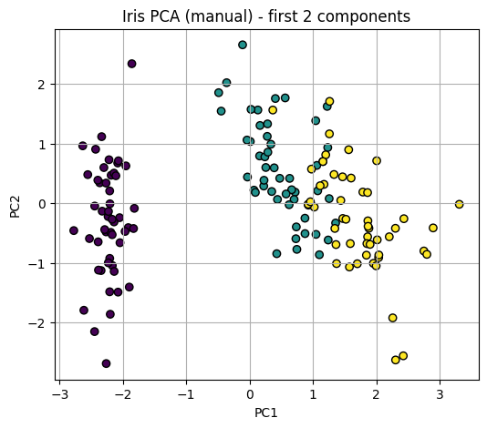

```python
plt.figure(figsize=(6,5))
plt.scatter(X_pca_2d[:, 0], X_pca_2d[:, 1], c=y_iris, cmap='viridis', edgecolor='k')
plt.xlabel("PC1")
plt.ylabel("PC2")
plt.title("Iris PCA (manual) - first 2 components")
# plt.colorbar(label='species')
plt.grid(True)
plt.show()
```

You should see that the **setosa** species cluster is often separated, while versicolor/virginica might overlap more in the 2D projection.

### 2.4 Compare with scikit-learn’s PCA

`scikit-learn` has a built-in `PCA` class that does all the above steps internally (using an SVD approach). Let's see if our results match.

```python
from sklearn.decomposition import PCA
pca = PCA(n_components=2)
X_pca_sklearn = pca.fit_transform(X_std)
print("Shape of X_pca_sklearn:", X_pca_sklearn.shape)

print("Explained variance ratio (sklearn):", pca.explained_variance_ratio_)
print("Sum of first 2 explained variance (sklearn):", np.sum(pca.explained_variance_ratio_))
```

```
Shape of X_pca_sklearn: (150, 2)
Explained variance ratio (sklearn): [0.72962445 0.22850762]
Sum of first 2 explained variance (sklearn): 0.9581320720000166
```

```python
# Compare the numeric results with X_pca_2d
# They might differ by a sign or small numerical differences (rotations, sign flips),
# but the relative distances and variance explained should be the same.
```

We might see a sign flip or minor numeric differences, because **eigenvectors** are not unique in direction (they can be multiplied by -1 and still be valid). The important part is that the subspace is the same, and the **variance explained** will match closely.

## 3. Key Takeaways

1. **Eigenvalues & Eigenvectors**:
   - Found by solving $A\mathbf{v} = \lambda \mathbf{v}$.
   - Describe how a matrix (linear transformation) scales/directionally transforms vectors.
   - Crucial in many ML algorithms (e.g., PCA, spectral clustering, stability analysis).
2. **PCA**:
   - Uses the eigen-decomposition of the **covariance matrix** to identify directions of **maximum variance**.
   - Allows us to **reduce dimensionality** while preserving as much variation in the data as possible.
   - The **eigenvalue** magnitudes indicate **how much variance** each principal component captures.
3. **Practical Tips**:
   - In real-world datasets, we often use scikit-learn’s `PCA` for convenience and numerical robustness.
   - Be mindful of **center/scale**: typically center data before PCA, sometimes also scale features if they have very different ranges.
   - Eigen-decomposition is more direct for smaller datasets; for large datasets, SVD-based approaches are usually preferred for efficiency and stability.

With these concepts, you have a strong basis for understanding how **eigenvalues, eigenvectors**, and **PCA** power many dimensionality reduction and feature extraction techniques in data science.

**Next Video**:We'lll discuss **SVD** (Singular Value Decomposition), which is intimately connected to eigen-decomposition but often more numerically stable and efficient for large matrices.